# Simulation study

Comapring Repeated- and Single-visit occupancy

Valentin Lauret, Hélène Labach, Matthieu Authier, Olivier Gimenez

Comparing single-visit and repeated-visits integrated occupancy models.

# Methods

## Data simulation

Required packages

```r
library(unmarked)
library(tidyverse)
library(cowplot)
```

### State process

The occupancy state `z` was drawn from a Bernoulli distribution with parameter ψ, `z <- dbern(Ψ)`. We wrote ψ as a logistic function of an environmental covariate cov:

$logit(\psi) = \alpha_{0} + \alpha_{1} cov$

where $\alpha_{0}$ and $\alpha_{1}$ are unknown parameters that need to be estimated.

We considered 4 sets of values for the alpha’s:

- `alpha0 = -1.9` and `alpha1 = 0.2` that led to ψ approx. equal to 0.1
- `alpha0 = -0.5` and `alpha1 = 0.2` that led to ψ approx. equal to 0.3
- `alpha0 = 0.5` and `alpha1 = 0.2` that led to ψ approx. equal to 0.5
- `alpha0 = 2.5` and `alpha1 = 0.15` that led to ψ approx. equal to 0.9

We used the `sim_state_cov()` function to simulate the `z` vector that contains the latent ecological state.

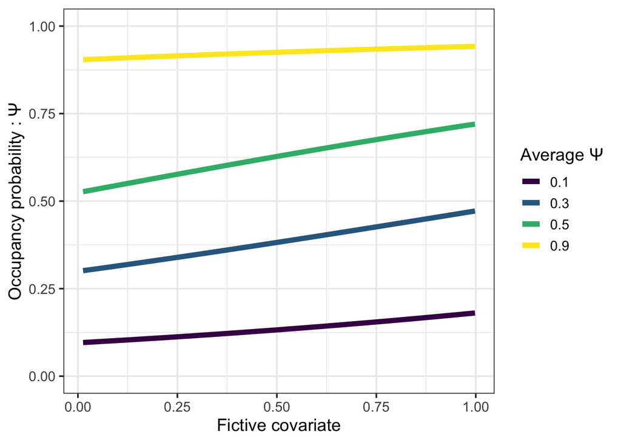

Fig.1: Occupancy probability as function of a fictive environmental covariate, 4 scenarii used for simulations

### Observation process

The observations are drawn either from a Bernoulli distribution with parameter p or a Multinomial distribution depending on two detection probability `p1` and `p2` for the integrated occupancy model. We wrote `p` as a logistic function of a sampling effort covariate `seff`:

$logit(p) = \beta_{0} + \beta_{1} seff$

where $\beta_{0}$ and $\beta_{1}$ are unknown parameters that need to be estimated.

We considered 4 sets of values for the beta’s:

- `beta0 = -1.5` and `beta1 = 0.26` that led to p approx. equal to 0.15
- `beta0 = -0.6` and `beta1 = 0.25` that led to p approx. equal to 0.35
- `beta0 = 0.3` and `beta1 = 0.26` that led to p approx. equal to 0.5
- `beta0 = 1.8` and `beta1 = 0.3` that led to p approx. equal to 0.8

We used the `sim_obs_cov()` function to simulate the `y` vector that contains the detections/non-detections.

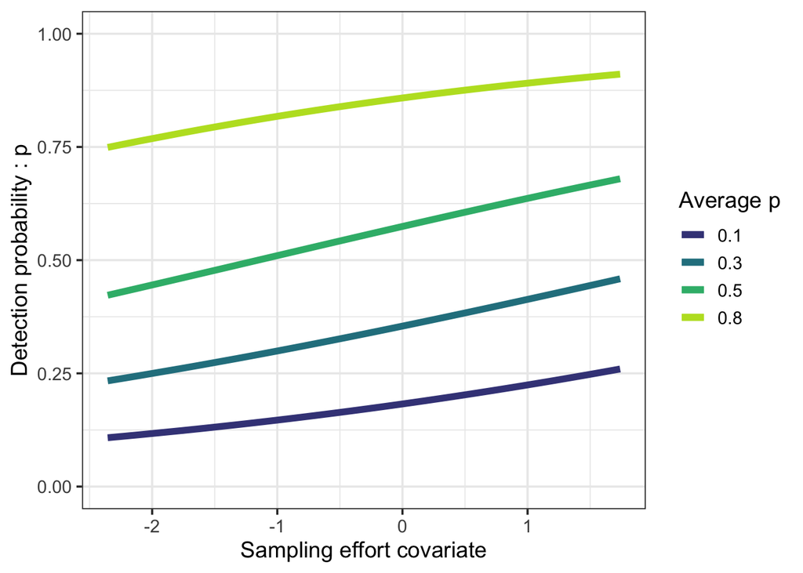

Fig.2: Detetion probability as function of a fictive sampling effort, 4 scenarii used for simulations

We simulated 4 different sampling occasions for repeated-visit occupancy. For single-visit occupancy, we formatted the data as described in the Methods section. For the sampling effort at site `i`, we summed the sampling effort over the 4 sampling occasions at site `i`, with `seff_sv <- apply(seff_rv,1,sum)`. For the detection/non-detection matrix, we considered the site as occupied if the species was detected at least once over the 4 sampling occasions, with `y_sv <- apply(y_rv,1,max)`.

### Study area

We simulated `z` and `y` for a study area of 100 sites.

## Models

For each combination of Ψ and p we fitted 2 occupancy models:

- Repeated-visit occupancy model (RV)
- Single-visit occupancy model (SV)

We have 16 ecological situations depending on Ψ and p.

For each scenario, we ran 100 simulations and fitted the 2 occupancy models.

## Performances

To compare the performances of the different occupancy models we calculated the relative bias RB, and the root mean square error over the `S = 100` simulations :

- Relative bias: $RB = \frac{1}{S} \sum_{1}^{S} \frac{(\widehat{\theta}_{s}-\theta)}{\theta}$
- Root Mean Square Error: $RMSE = \sqrt{ \frac{1}{S} \sum_{1}^{S} (\widehat{\theta}_{s}-\theta)^2}$

# Results

## Occupancy estimation

Regarding the covariate effect size on $\Psi$ (Fig.3), we found slightly greater RMSE and RB for single-visit occupancy in most scenario, except in the case, of high occupancy (`\Psi = 0.9`) and low detection probability (`p = 0.1` or `p = 0.3`) where differences are greater. Overall, the results were similar whatever the occupancy models we considered.

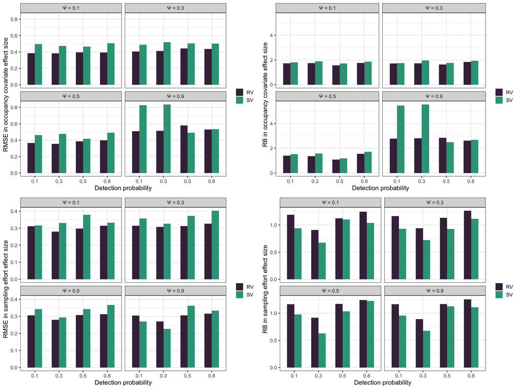

Fig. 3: RMSE and RB for all occupancy models

## Detection probability

Regarding the sampling effort effect size on p (Fig.3), we also found a similar RMSE and RB whatever the occupancy model considered.

# Discussion

Our simulations study showed that single-visit and repeated-visit occupancy models had similar results in the estimation of covariate effect size for both ocucpancy and detection probabilities. To be consistent with our manuscript, we reported performances of covariates effect size and explored simple logistic regressions to describe models paramters. To have a complete understanding of models performances, one might wants to look at wider range of relationships, and observe all models parameters (e.g. intercept).